# Natural Language Processing Nanodegree

## Machine Translation Project

In this notebook, sections that end with **'(IMPLEMENTATION)'** in the header indicate that the following blocks of code will require additional functionality which you must provide. Please be sure to read the instructions carefully!

## Introduction

In this notebook, you will build a deep neural network that functions as part of an end-to-end machine translation pipeline. Your completed pipeline will accept English text as input and return the French translation.

- **Preprocess** - You'll convert text to sequence of integers.
- **Models** Create models which accepts a sequence of integers as input and returns a probability distribution over possible translations. After learning about the basic types of neural networks that are often used for machine translation, you will engage in your own investigations, to design your own model!
- **Prediction** Run the model on English text.

```python
%load_ext autoreload
%aimport helper, tests
%autoreload 1
```

```python
import os
import collections
import random
random.seed(42)

import helper
import project_tests as tests
import matplotlib.pyplot as plt

import numpy as np
np.random.seed(42)

import tensorflow as tf
tf.get_logger().setLevel('ERROR')
tf.autograph.set_verbosity(3)
tf.set_random_seed(42)

from keras.preprocessing.text import Tokenizer
from keras.preprocessing.sequence import pad_sequences
from keras.models import Model, Sequential
from keras.layers import GRU, Input, Dense, Dropout, Embedding, TimeDistributed, RepeatVector, Bidirectional
from keras.optimizers import Adam
from keras.losses import sparse_categorical_crossentropy
from keras.utils import plot_model
```

### Verify access to the GPU

The following test applies only if you expect to be using a GPU, e.g., while running in a Udacity Workspace or using an AWS instance with GPU support. Run the next cell, and verify that the device_type is "GPU".

- If the device is not GPU & you are running from a Udacity Workspace, then save your workspace with the icon at the top, then click "enable" at the bottom of the workspace.
- If the device is not GPU & you are running from an AWS instance, then refer to the cloud computing instructions in the classroom to verify your setup steps.

```python
from tensorflow.python.client import device_lib
print(device_lib.list_local_devices())
```

```
[name: "/device:CPU:0"
device_type: "CPU"
memory_limit: 268435456
locality {
}
incarnation: 8057472806296190390
, name: "/device:GPU:0"
device_type: "GPU"
memory_limit: 3141979342
locality {
  bus_id: 1
  links {
  }
}
incarnation: 18188635996353008301
physical_device_desc: "device: 0, name: Quadro P2000, pci bus id: 0000:01:00.0, compute capability: 6.1"
]
```

## Dataset

We begin by investigating the dataset that will be used to train and evaluate your pipeline. The most common datasets used for machine translation are from [WMT](http://www.statmt.org/). However, that will take a long time to train a neural network on. We'll be using a dataset we created for this project that contains a small vocabulary. You'll be able to train your model in a reasonable time with this dataset.

### Load Data

The data is located in `data/small_vocab_en` and `data/small_vocab_fr`. The `small_vocab_en` file contains English sentences with their French translations in the `small_vocab_fr` file. Load the English and French data from these files from running the cell below.

```python
# Load English data
english_sentences = helper.load_data('data/small_vocab_en')
# Load French data
french_sentences = helper.load_data('data/small_vocab_fr')

print('Dataset Loaded')
```

```
Dataset Loaded
```

### Files

Each line in `small_vocab_en` contains an English sentence with the respective translation in each line of `small_vocab_fr`. View the first two lines from each file.

```python
for sample_i in range(2):
    print('small_vocab_en Line {}:  {}'.format(sample_i+1, english_sentences[sample_i]))
    print('small_vocab_fr Line {}:  {}'.format(sample_i+1, french_sentences[sample_i]))
```

```
small_vocab_en Line 1:  new jersey is sometimes quiet during autumn , and it is snowy in april .
small_vocab_fr Line 1:  new jersey est parfois calme pendant l' automne , et il est neigeux en avril .
small_vocab_en Line 2:  the united states is usually chilly during july , and it is usually freezing in november .
small_vocab_fr Line 2:  les états-unis est généralement froid en juillet , et il gèle habituellement en novembre .
```

From looking at the sentences, you can see they have been preprocessed already. The puncuations have been delimited using spaces. All the text have been converted to lowercase. This should save you some time, but the text requires more preprocessing.

### Vocabulary

The complexity of the problem is determined by the complexity of the vocabulary. A more complex vocabulary is a more complex problem. Let's look at the complexity of the dataset we'll be working with.

```python
english_words_counter = collections.Counter([word for sentence in english_sentences for word in sentence.split()])
french_words_counter = collections.Counter([word for sentence in french_sentences for word in sentence.split()])

print('{} English words.'.format(len([word for sentence in english_sentences for word in sentence.split()])))
print('{} unique English words.'.format(len(english_words_counter)))
print('10 Most common words in the English dataset:')
print('"'+'" "'.join(list(zip(*english_words_counter.most_common(10)))[0])+'"')
print()
print('{} French words.'.format(len([word for sentence in french_sentences for word in sentence.split()])))
print('{} unique French words.'.format(len(french_words_counter)))
print('10 Most common words in the French dataset:')
print('"'+'" "'.join(list(zip(*french_words_counter.most_common(10)))[0])+'"')
```

```
1823250 English words.
227 unique English words.
10 Most common words in the English dataset:
"is" "," "." "in" "it" "during" "the" "but" "and" "sometimes"

1961295 French words.
355 unique French words.
10 Most common words in the French dataset:
"est" "." "," "en" "il" "les" "mais" "et" "la" "parfois"
```

For comparison, *Alice's Adventures in Wonderland* contains 2,766 unique words of a total of 15,500 words.

## Preprocess

For this project, you won't use text data as input to your model. Instead, you'll convert the text into sequences of integers using the following preprocess methods:

1. Tokenize the words into ids
2. Add padding to make all the sequences the same length.

Time to start preprocessing the data...

### Tokenize (IMPLEMENTATION)

For a neural network to predict on text data, it first has to be turned into data it can understand. Text data like "dog" is a sequence of ASCII character encodings. Since a neural network is a series of multiplication and addition operations, the input data needs to be number(s).

We can turn each character into a number or each word into a number. These are called character and word ids, respectively. Character ids are used for character level models that generate text predictions for each character. A word level model uses word ids that generate text predictions for each word. Word level models tend to learn better, since they are lower in complexity, so we'll use those.

Turn each sentence into a sequence of words ids using Keras's [`Tokenizer`](https://keras.io/preprocessing/text/#tokenizer) function. Use this function to tokenize `english_sentences` and `french_sentences` in the cell below.

Running the cell will run `tokenize` on sample data and show output for debugging.

```python
def tokenize(x, verbose=False):
    """
    Tokenize x
    :param x: List of sentences/strings to be tokenized
    :return: Tuple of (tokenized x data, tokenizer used to tokenize x)
    """
    # generate the tokenizer
    tokenizer = Tokenizer()
    tokenizer.fit_on_texts(x)
    # tokenize the sentences
    tokenized_x = tokenizer.texts_to_sequences(x)
    # print tokenizer summary
    if verbose:
        print(tokenizer.word_counts)
        print(tokenizer.document_count)
        print(tokenizer.word_index)
        print(tokenizer.word_docs)

    return tokenized_x, tokenizer
```

```python
# Test the tokenizer function
tests.test_tokenize(tokenize)

# Tokenize Example output
text_sentences = ['The quick brown fox jumps over the lazy dog .',
                  'By Jove , my quick study of lexicography won a prize .',
                  'This is a short sentence .']
text_tokenized, text_tokenizer = tokenize(text_sentences)
print(text_tokenizer.word_index)
print()
for sample_i, (sent, token_sent) in enumerate(zip(text_sentences, text_tokenized)):
    print('Sequence {} in x'.format(sample_i+1))
    print('  Input:  {}'.format(sent))
    print('  Output: {}'.format(token_sent))
```

```
{'the': 1, 'quick': 2, 'a': 3, 'brown': 4, 'fox': 5, 'jumps': 6, 'over': 7, 'lazy': 8, 'dog': 9, 'by': 10, 'jove': 11, 'my': 12, 'study': 13, 'of': 14, 'lexicography': 15, 'won': 16, 'prize': 17, 'this': 18, 'is': 19, 'short': 20, 'sentence': 21}

Sequence 1 in x
  Input:  The quick brown fox jumps over the lazy dog .
  Output: [1, 2, 4, 5, 6, 7, 1, 8, 9]
Sequence 2 in x
  Input:  By Jove , my quick study of lexicography won a prize .
  Output: [10, 11, 12, 2, 13, 14, 15, 16, 3, 17]
Sequence 3 in x
  Input:  This is a short sentence .
  Output: [18, 19, 3, 20, 21]
```

### Padding (IMPLEMENTATION)

When batching the sequence of word ids together, each sequence needs to be the same length. Since sentences are dynamic in length, we can add padding to the end of the sequences to make them the same length.

Make sure all the English sequences have the same length and all the French sequences have the same length by adding padding to the **end** of each sequence using Keras's [`pad_sequences`](https://keras.io/preprocessing/sequence/#pad_sequences) function.

```python
def pad(x, length=None):
    """
    Pad x
    :param x: List of sequences
    :param length: Length to pad the sequence to; if None, use length of longest sequence in x
    :return: Padded numpy array of sequences
    """
    # pad sequences with given max length at the end
    return pad_sequences(x, maxlen=length, padding='post')
```

```python
# Test pad function
tests.test_pad(pad)

# Pad Tokenized output
test_pad = pad(text_tokenized)
for sample_i, (token_sent, pad_sent) in enumerate(zip(text_tokenized, test_pad)):
    print('Sequence {} in x'.format(sample_i+1))
    print('  Input:  {}'.format(np.array(token_sent)))
    print('  Output: {}'.format(pad_sent))
```

```
Sequence 1 in x
  Input:  [1 2 4 5 6 7 1 8 9]
  Output: [1 2 4 5 6 7 1 8 9 0]
Sequence 2 in x
  Input:  [10 11 12  2 13 14 15 16  3 17]
  Output: [10 11 12  2 13 14 15 16  3 17]
Sequence 3 in x
  Input:  [18 19  3 20 21]
  Output: [18 19  3 20 21  0  0  0  0  0]
```

### Preprocess Pipeline

Your focus for this project is to build neural network architecture, so we won't ask you to create a preprocess pipeline. Instead, we've provided you with the implementation of the `preprocess` function.

```python
def preprocess(x, y):
    """
    Preprocess x and y
    :param x: Feature List of sentences
    :param y: Label List of sentences
    :return: Tuple of (Preprocessed x, Preprocessed y, x tokenizer, y tokenizer)
    """
    preprocess_x, x_tk = tokenize(x)
    preprocess_y, y_tk = tokenize(y)

    preprocess_x = pad(preprocess_x)
    preprocess_y = pad(preprocess_y)

    # Keras's sparse_categorical_crossentropy function requires the labels to be in 3 dimensions
    preprocess_y = preprocess_y.reshape(*preprocess_y.shape, 1)

    return preprocess_x, preprocess_y, x_tk, y_tk
```

```python
preproc_english_sentences, preproc_french_sentences, english_tokenizer, french_tokenizer =\
    preprocess(english_sentences, french_sentences)

max_english_sequence_length = preproc_english_sentences.shape[1]
max_french_sequence_length = preproc_french_sentences.shape[1]
english_vocab_size = len(english_tokenizer.word_index) + 1
french_vocab_size = len(french_tokenizer.word_index) + 1

print('Data Preprocessed')
print("Max English sentence length:", max_english_sequence_length)
print("Max French sentence length:", max_french_sequence_length)
print("English vocabulary size:", english_vocab_size)
print("French vocabulary size:", french_vocab_size)
```

```
Data Preprocessed
Max English sentence length: 15
Max French sentence length: 21
English vocabulary size: 200
French vocabulary size: 345
```

## Models

In this section, you will experiment with various neural network architectures. You will begin by training four relatively simple architectures.

- Model 1 is a simple RNN
- Model 2 is a RNN with Embedding
- Model 3 is a Bidirectional RNN
- Model 4 is an optional Encoder-Decoder RNN

After experimenting with the four simple architectures, you will construct a deeper architecture that is designed to outperform all four models.

### Ids Back to Text

The neural network will be translating the input to words ids, which isn't the final form we want. We want the French translation. The function `logits_to_text` will bridge the gap between the logits from the neural network to the French translation. You'll be using this function to better understand the output of the neural network.

```python
def logits_to_text(logits, tokenizer):
    """
    Turn logits from a neural network into text using the tokenizer
    :param logits: Logits from a neural network
    :param tokenizer: Keras Tokenizer fit on the labels
    :return: String that represents the text of the logits
    """
    index_to_words = {id: word for word, id in tokenizer.word_index.items()}
    index_to_words[0] = '<PAD>'

    return ' '.join([index_to_words[prediction] for prediction in np.argmax(logits, 1)])

print('`logits_to_text` function loaded.')
```

```
`logits_to_text` function loaded.
```

```python
def train_model(name, inputs, labels, batch_size=1024, epochs=10, split=0.2, learning_rate=10e-3, same_length=True):

    inp_prc, lab_prc, inp_tok, lab_tok = preprocess(inputs, labels)
    inp_seq_len = lab_prc.shape[1] if same_length else inp_prc.shape[1]
    lab_seq_len = lab_prc.shape[1]
    inp_vocab_size = len(inp_tok.word_index) + 1
    lab_vocab_size = len(lab_tok.word_index) + 1

    if same_length:
        inp_prc = pad(inp_prc, lab_seq_len)

    if 'simple_rnn' == name:
        model = simple_model(inp_prc.shape, lab_seq_len, inp_vocab_size, lab_vocab_size, learning_rate, name)
    elif 'embed_rnn' == name:
        model = embed_model(inp_prc.shape, lab_seq_len, inp_vocab_size, lab_vocab_size, learning_rate, name)
    elif 'bd_rnn' == name:
        model = bd_model(inp_prc.shape, lab_seq_len, inp_vocab_size, lab_vocab_size, learning_rate, name)
    elif 'encdec_rnn' == name:
        model = encdec_model(inp_prc.shape, lab_seq_len, inp_vocab_size, lab_vocab_size, learning_rate, name)
    elif 'final_rnn' == name:
        model = model_final(inp_prc.shape, lab_seq_len, inp_vocab_size, lab_vocab_size, learning_rate, name)
    else:
        raise Exception('ERROR! Unsupported model: {}'.format(model_name))

    if isinstance(model, Sequential):
        model = model.model

    if len(model.input_shape) > 2:
        inp_prc = inp_prc.reshape(-1, model.input_shape[1], model.input_shape[2])

    model.summary()
    model.fit(inp_prc, lab_prc, batch_size=batch_size, epochs=epochs, validation_split=split, verbose=2)

    return model

print('`train_model` function loaded.')
```

```
`train_model` function loaded.
```

```python
def test_model(model, inputs, labels, n=-1, languages=('English', 'French'), same_length=True):

    inp_prc, lab_prc, _, lab_tok = preprocess(inputs, labels)

    if same_length:
        inp_prc = pad(inp_prc, lab_prc.shape[1])

    if isinstance(model, Sequential):
        model = model.model

    if len(model.input_shape) > 2:
        inp_prc = inp_prc.reshape(-1, model.input_shape[1], model.input_shape[2])

    if n < 0 or n > inp_prc.shape[0]:
        n = random.randint(0, inp_prc.shape[0])

    print('{}:'.format(languages[0]))
    print(inputs[n:n+1][0])

    print('{}:'.format(languages[1]))
    print(labels[n:n+1][0])

    print('Translation:')
    sample = logits_to_text(model.predict(inp_prc[n:n+1])[0], lab_tok)
    sample = sample[:sample.find('<PAD>')]
    print('{}.'.format(sample))

print('`test_model` function loaded.')
```

```
`test_model` function loaded.
```

```python
def plot_metrics(model):

    if isinstance(model, Sequential):
        model = model.model

    plt.figure(figsize=(10, 8), dpi=100)
    plt.subplot(211)
    plt.plot(model.history.history['loss'], label='Train Loss')
    plt.plot(model.history.history['val_loss'], label='Valid Loss')
    plt.legend()
    plt.subplot(212)
    plt.plot(model.history.history['acc'], label='Train Accuracy')
    plt.plot(model.history.history['val_acc'], label='Valid Accuracy')
    plt.legend()

print('`plot_metrics` function loaded.')
```

```
`plot_metrics` function loaded.
```

```python
def plot_comparison(models):

    plt.figure(figsize=(10, 8), dpi=100)

    for model in models:

        if isinstance(model, Sequential):
            model = model.model

        name = model.name

        plt.plot(model.history.history['val_acc'], label=name)
        plot_model(model, to_file='./images/{}.png'.format(name), show_shapes=False, show_layer_names=False, rankdir='TB')

    plt.legend()
    plt.title('Valid Accuracy')
    plt.savefig('./images/rnn_model_comparison.png', dpi=300)

print('`plot_comparison` function loaded.')
```

```
`plot_comparison` function loaded.
```

### Model 1: RNN (IMPLEMENTATION)

[figure not shown]

A basic RNN model is a good baseline for sequence data. In this model, you'll build a RNN that translates English to French.

```python
def simple_model(input_shape, output_sequence_length, english_vocab_size, french_vocab_size, learning_rate=10e-3, name=''):
    """
    Build and train a basic RNN on x and y
    :param input_shape: Tuple of input shape
    :param output_sequence_length: Length of output sequence
    :param english_vocab_size: Number of unique English words in the dataset
    :param french_vocab_size: Number of unique French words in the dataset
    :return: Keras model built, but not trained
    """
    # define sequence length
    assert(input_shape[1] == output_sequence_length)
    sequence_length = output_sequence_length
    # define the simple rnn model with one GRU layer
    model = Sequential(name=name)
    model.add(GRU(english_vocab_size, return_sequences=True, input_shape=(sequence_length, 1), name='rnn'))
    model.add(TimeDistributed(Dense(french_vocab_size, activation='softmax'), name='class'))
    # compile the model with optimization options
    model.compile(loss=sparse_categorical_crossentropy, optimizer=Adam(learning_rate), metrics=['accuracy'])
    # return the compiled model
    return model
```

```python
# Test simple_model function
tests.test_simple_model(simple_model)
```

```python
# Train the neural network
simple_rnn_model = train_model('simple_rnn', english_sentences, french_sentences)
```

```
_________________________________________________________________
Layer (type)                 Output Shape              Param #
=================================================================
rnn_input (InputLayer)       (None, 21, 1)             0
_________________________________________________________________
rnn (GRU)                    (None, 21, 200)           121200
_________________________________________________________________
class (TimeDistributed)      (None, 21, 345)           69345
=================================================================
Total params: 190,545
Trainable params: 190,545
Non-trainable params: 0
_________________________________________________________________
Train on 110288 samples, validate on 27573 samples
 - 10s - loss: 1.7326 - acc: 0.5739 - val_loss: 1.2472 - val_acc: 0.6406
 - 9s - loss: 1.1396 - acc: 0.6583 - val_loss: 1.0531 - val_acc: 0.6700
 - 10s - loss: 1.0128 - acc: 0.6758 - val_loss: 0.9639 - val_acc: 0.6847
 - 10s - loss: 0.9420 - acc: 0.6884 - val_loss: 0.9128 - val_acc: 0.6963
 - 10s - loss: 0.8930 - acc: 0.7001 - val_loss: 0.8889 - val_acc: 0.6941
 - 10s - loss: 0.8612 - acc: 0.7065 - val_loss: 0.8695 - val_acc: 0.6990
 - 10s - loss: 0.8220 - acc: 0.7214 - val_loss: 0.8163 - val_acc: 0.7223
 - 10s - loss: 0.8192 - acc: 0.7158 - val_loss: 0.7865 - val_acc: 0.7288
 - 10s - loss: 0.7784 - acc: 0.7327 - val_loss: 0.7499 - val_acc: 0.7508
 - 10s - loss: 0.7703 - acc: 0.7373 - val_loss: 0.7334 - val_acc: 0.7600
```

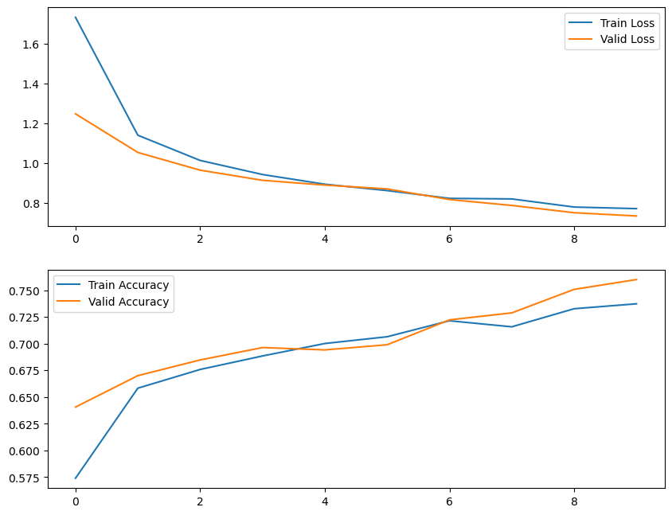

```python
# Display training metric values
plot_metrics(simple_rnn_model)
```

```python
# Print prediction(s)
test_model(simple_rnn_model, english_sentences, french_sentences)
```

```
English:
she likes bananas , mangoes , and pears .
French:
elle aime les bananes , les mangues et les poires .
Translation:
elle aime les bananes les pommes et les oranges .
```

### Model 2: Embedding (IMPLEMENTATION)

[figure not shown]

You've turned the words into ids, but there's a better representation of a word. This is called word embeddings. An embedding is a vector representation of the word that is close to similar words in n-dimensional space, where the n represents the size of the embedding vectors.

In this model, you'll create a RNN model using embedding.

```python
def embed_model(input_shape, output_sequence_length, english_vocab_size, french_vocab_size, learning_rate=10e-3, name=''):
    """
    Build and train a RNN model using word embedding on x and y
    :param input_shape: Tuple of input shape
    :param output_sequence_length: Length of output sequence
    :param english_vocab_size: Number of unique English words in the dataset
    :param french_vocab_size: Number of unique French words in the dataset
    :return: Keras model built, but not trained
    """
    # define sequence length
    assert(input_shape[1] == output_sequence_length)
    sequence_length = output_sequence_length
    # define the rnn model with one Embedding and GRU layer
    # note: dimensionality reduction of the representation
    model = Sequential(name=name)
    model.add(Embedding(english_vocab_size, 128, input_length=sequence_length, name='embed'))
    model.add(GRU(128, return_sequences=True, name='rnn'))
    model.add(TimeDistributed(Dense(french_vocab_size, activation='softmax'), name='class'))
    # compile the model with optimization options
    model.compile(loss=sparse_categorical_crossentropy, optimizer=Adam(learning_rate), metrics=['accuracy'])
    # return the compiled model
    return model
```

```python
# Test embed_model function
tests.test_embed_model(embed_model)
```

```python
# Train the neural network
embed_rnn_model = train_model('embed_rnn', english_sentences, french_sentences)
```

```
_________________________________________________________________
Layer (type)                 Output Shape              Param #
=================================================================
embed_input (InputLayer)     (None, 21)                0
_________________________________________________________________
embed (Embedding)            (None, 21, 128)           25600
_________________________________________________________________
rnn (GRU)                    (None, 21, 128)           98688
_________________________________________________________________
class (TimeDistributed)      (None, 21, 345)           44505
=================================================================
Total params: 168,793
Trainable params: 168,793
Non-trainable params: 0
_________________________________________________________________
Train on 110288 samples, validate on 27573 samples
 - 10s - loss: 1.4849 - acc: 0.6645 - val_loss: 0.5379 - val_acc: 0.8330
 - 9s - loss: 0.3986 - acc: 0.8756 - val_loss: 0.3158 - val_acc: 0.9001
 - 8s - loss: 0.2836 - acc: 0.9085 - val_loss: 0.2644 - val_acc: 0.9141
 - 9s - loss: 0.2469 - acc: 0.9187 - val_loss: 0.2404 - val_acc: 0.9209
 - 9s - loss: 0.2256 - acc: 0.9246 - val_loss: 0.2287 - val_acc: 0.9247
 - 9s - loss: 0.2152 - acc: 0.9271 - val_loss: 0.2193 - val_acc: 0.9273
 - 9s - loss: 0.2065 - acc: 0.9294 - val_loss: 0.2119 - val_acc: 0.9275
 - 9s - loss: 0.2023 - acc: 0.9304 - val_loss: 0.2105 - val_acc: 0.9287
 - 9s - loss: 0.1978 - acc: 0.9316 - val_loss: 0.2100 - val_acc: 0.9290
 - 9s - loss: 0.1949 - acc: 0.9324 - val_loss: 0.2059 - val_acc: 0.9298
```

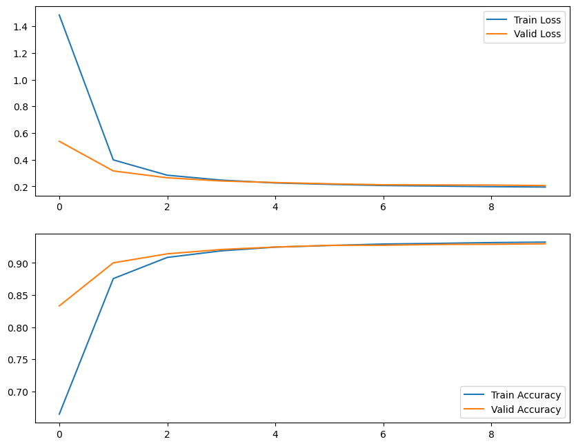

```python
# Display training metric values
plot_metrics(embed_rnn_model)
```

```python
# Print prediction(s)
test_model(embed_rnn_model, english_sentences, french_sentences)
```

```
English:
california is usually snowy during summer , and it is usually wonderful in august .
French:
californie est généralement enneigée pendant l' été , et il est généralement merveilleux en août .
Translation:
californie est généralement enneigée en l' été et il est généralement merveilleux en août .
```

### Model 3: Bidirectional RNNs (IMPLEMENTATION)

[figure not shown]

One restriction of a RNN is that it can't see the future input, only the past. This is where bidirectional recurrent neural networks come in. They are able to see the future data.

```python
def bd_model(input_shape, output_sequence_length, english_vocab_size, french_vocab_size, learning_rate=10e-3, name=''):
    """
    Build and train a bidirectional RNN model on x and y
    :param input_shape: Tuple of input shape
    :param output_sequence_length: Length of output sequence
    :param english_vocab_size: Number of unique English words in the dataset
    :param french_vocab_size: Number of unique French words in the dataset
    :return: Keras model built, but not trained
    """
    # define sequence length
    assert(input_shape[1] == output_sequence_length)
    sequence_length = output_sequence_length
    # define the bidirectional rnn model with one GRU layer
    model = Sequential(name=name)
    model.add(Bidirectional(GRU(english_vocab_size, return_sequences=True), input_shape=(sequence_length, 1), name='rnn'))
    model.add(TimeDistributed(Dense(french_vocab_size, activation='softmax'), name='class'))
    # compile the model with optimization options
    model.compile(loss=sparse_categorical_crossentropy, optimizer=Adam(learning_rate), metrics=['accuracy'])
    # return the compiled model
    return model
```

```python
# Test bd_model function
tests.test_bd_model(bd_model)
```

```python
# Train the neural network
bd_rnn_model = train_model('bd_rnn', english_sentences, french_sentences)
```

```
_________________________________________________________________
Layer (type)                 Output Shape              Param #
=================================================================
rnn_input (InputLayer)       (None, 21, 1)             0
_________________________________________________________________
rnn (Bidirectional)          (None, 21, 400)           242400
_________________________________________________________________
class (TimeDistributed)      (None, 21, 345)           138345
=================================================================
Total params: 380,745
Trainable params: 380,745
Non-trainable params: 0
_________________________________________________________________
Train on 110288 samples, validate on 27573 samples
 - 19s - loss: 1.5330 - acc: 0.6126 - val_loss: 1.1307 - val_acc: 0.6639
 - 17s - loss: 1.0356 - acc: 0.6816 - val_loss: 0.9597 - val_acc: 0.6925
 - 17s - loss: 0.9223 - acc: 0.6986 - val_loss: 0.8702 - val_acc: 0.7088
 - 16s - loss: 0.8505 - acc: 0.7120 - val_loss: 0.8214 - val_acc: 0.7167
 - 15s - loss: 0.8099 - acc: 0.7207 - val_loss: 0.7874 - val_acc: 0.7273
 - 16s - loss: 0.7715 - acc: 0.7308 - val_loss: 0.7939 - val_acc: 0.7239
 - 15s - loss: 0.7416 - acc: 0.7402 - val_loss: 0.7400 - val_acc: 0.7434
 - 16s - loss: 0.7076 - acc: 0.7524 - val_loss: 0.6854 - val_acc: 0.7648
 - 16s - loss: 0.6819 - acc: 0.7625 - val_loss: 0.6925 - val_acc: 0.7580
 - 15s - loss: 0.6376 - acc: 0.7792 - val_loss: 0.6241 - val_acc: 0.7856
```

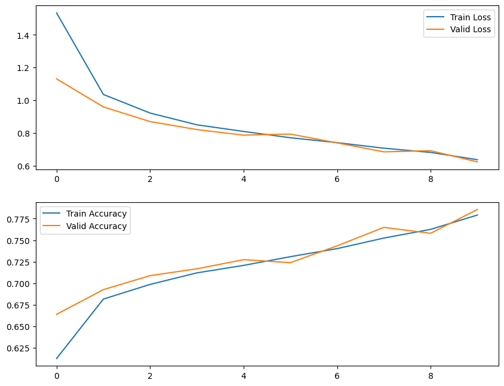

```python
# Display training metric values
plot_metrics(bd_rnn_model)
```

```python
# Print prediction(s)
test_model(bd_rnn_model, english_sentences, french_sentences)
```

```
English:
he saw a old black truck .
French:
il a vu un vieux camion noir .
Translation:
il a conduit cette voiture voiture .
```

### Model 4: Encoder-Decoder (OPTIONAL)

Time to look at encoder-decoder models. This model is made up of an encoder and decoder. The encoder creates a matrix representation of the sentence. The decoder takes this matrix as input and predicts the translation as output.

Create an encoder-decoder model in the cell below.

```python
def encdec_model(input_shape, output_sequence_length, english_vocab_size, french_vocab_size, learning_rate=10e-3, name=''):
    """
    Build and train an encoder-decoder model on x and y
    :param input_shape: Tuple of input shape
    :param output_sequence_length: Length of output sequence
    :param english_vocab_size: Number of unique English words in the dataset
    :param french_vocab_size: Number of unique French words in the dataset
    :return: Keras model built, but not trained
    """
    # define input sequence length
    input_sequence_length = input_shape[1]
    # define the encoder
    encoder_inputs = Input((input_sequence_length, 1), name='en_inp')
    encoder = GRU(english_vocab_size, return_sequences=False, return_state=True, name='en_rnn')
    encoder_outputs, encoder_state_h = encoder(encoder_inputs)
    # define the decoder
    decoder_inputs = RepeatVector(output_sequence_length, name='de_inp')(encoder_outputs)
    decoder_gru = GRU(english_vocab_size, return_sequences=True, return_state=False, name='de_rnn')
    decoder_outputs = decoder_gru(decoder_inputs, initial_state=encoder_state_h)
    decoder_dense = TimeDistributed(Dense(french_vocab_size, activation='softmax'), name='class')
    decoder_outputs = decoder_dense(decoder_outputs)
    # define the model
    model = Model(encoder_inputs, decoder_outputs, name='{}_model'.format(name))
    # compile the model with optimization options
    model.compile(loss=sparse_categorical_crossentropy, optimizer=Adam(learning_rate), metrics=['accuracy'])
    # return the compiled model
    return model
```

```python
# Test encdec_model function
tests.test_encdec_model(encdec_model)
```

```python
# Train the neural network
encdec_rnn_model = train_model('encdec_rnn', english_sentences, french_sentences, same_length=False)
```

```
__________________________________________________________________________________________________
Layer (type)                    Output Shape         Param #     Connected to
==================================================================================================
en_inp (InputLayer)             (None, 15, 1)        0
__________________________________________________________________________________________________
en_rnn (GRU)                    [(None, 200), (None, 121200      en_inp[0][0]
__________________________________________________________________________________________________
de_inp (RepeatVector)           (None, 21, 200)      0           en_rnn[0][0]
__________________________________________________________________________________________________
de_rnn (GRU)                    (None, 21, 200)      240600      de_inp[0][0]
                                                                 en_rnn[0][1]
__________________________________________________________________________________________________
class (TimeDistributed)         (None, 21, 345)      69345       de_rnn[0][0]
==================================================================================================
Total params: 431,145
Trainable params: 431,145
Non-trainable params: 0
__________________________________________________________________________________________________
Train on 110288 samples, validate on 27573 samples
 - 16s - loss: 2.3328 - acc: 0.4797 - val_loss: 1.6759 - val_acc: 0.5717
 - 15s - loss: 1.4914 - acc: 0.5987 - val_loss: 1.3521 - val_acc: 0.6173
 - 15s - loss: 1.2775 - acc: 0.6374 - val_loss: 1.2168 - val_acc: 0.6526
 - 15s - loss: 1.2118 - acc: 0.6480 - val_loss: 1.1649 - val_acc: 0.6637
 - 16s - loss: 1.1881 - acc: 0.6550 - val_loss: 1.1856 - val_acc: 0.6574
 - 15s - loss: 1.0935 - acc: 0.6787 - val_loss: 1.0525 - val_acc: 0.6873
 - 15s - loss: 1.0855 - acc: 0.6768 - val_loss: 1.0232 - val_acc: 0.6905
 - 15s - loss: 1.0800 - acc: 0.6761 - val_loss: 1.1739 - val_acc: 0.6493
 - 15s - loss: 1.0589 - acc: 0.6792 - val_loss: 0.9888 - val_acc: 0.6958
 - 15s - loss: 1.1102 - acc: 0.6676 - val_loss: 1.0250 - val_acc: 0.6871
```

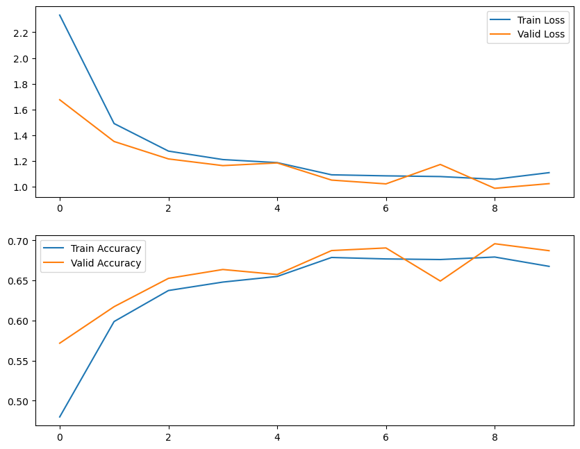

```python
# Display training metric values
plot_metrics(encdec_rnn_model)
```

```python
# Print prediction(s)
test_model(encdec_rnn_model, english_sentences, french_sentences, same_length=False)
```

```
English:
france is warm during winter , but it is usually wonderful in june .
French:
france est chaud pendant l' hiver , mais il est généralement merveilleux en juin .
Translation:
la est est au mois mais il mais est est en en .
```

### Model 5: Custom (IMPLEMENTATION)

Use everything you learned from the previous models to create a model that incorporates embedding and a bidirectional rnn into one model.

```python
def model_final(input_shape, output_sequence_length, english_vocab_size, french_vocab_size, learning_rate=10e-3, name=''):
    """
    Build and train a model that incorporates embedding, encoder-decoder, and bidirectional RNN on x and y
    :param input_shape: Tuple of input shape
    :param output_sequence_length: Length of output sequence
    :param english_vocab_size: Number of unique English words in the dataset
    :param french_vocab_size: Number of unique French words in the dataset
    :return: Keras model built, but not trained
    """
    # define input sequence length
    input_sequence_length = input_shape[1]
    # define the encoder
    model = Sequential(name='final_rnn')
    model.add(Embedding(english_vocab_size, 128, input_length=input_sequence_length, name='en_emb'))
    model.add(Bidirectional(GRU(128, return_sequences=False), name='en_rnn'))
    # define the decoder
    model.add(RepeatVector(output_sequence_length, name='de_rnn_input'))
    model.add(Bidirectional(GRU(128, return_sequences=True, return_state=False), name='de_rnn'))
    model.add(TimeDistributed(Dense(256, activation='relu'), name='de_dense'))
    model.add(TimeDistributed(Dropout(0.25), name='de_reg'))
    model.add(TimeDistributed(Dense(french_vocab_size, activation='softmax'), name='class'))
    # compile the model with optimization options
    model.compile(loss=sparse_categorical_crossentropy, optimizer=Adam(learning_rate), metrics=['accuracy'])
    # return the compiled model
    return model
```

```python
# Test model_final function
tests.test_model_final(model_final)
```

```python
# Train the neural network
final_rnn_model = train_model('final_rnn', english_sentences, french_sentences, same_length=False)
```

```
_________________________________________________________________
Layer (type)                 Output Shape              Param #
=================================================================
en_emb_input (InputLayer)    (None, 15)                0
_________________________________________________________________
en_emb (Embedding)           (None, 15, 128)           25600
_________________________________________________________________
en_rnn (Bidirectional)       (None, 256)               197376
_________________________________________________________________
de_rnn_input (RepeatVector)  (None, 21, 256)           0
_________________________________________________________________
de_rnn (Bidirectional)       (None, 21, 256)           295680
_________________________________________________________________
de_dense (TimeDistributed)   (None, 21, 256)           65792
_________________________________________________________________
de_reg (TimeDistributed)     (None, 21, 256)           0
_________________________________________________________________
class (TimeDistributed)      (None, 21, 345)           88665
=================================================================
Total params: 673,113
Trainable params: 673,113
Non-trainable params: 0
_________________________________________________________________
Train on 110288 samples, validate on 27573 samples
 - 24s - loss: 2.2235 - acc: 0.5038 - val_loss: 1.4410 - val_acc: 0.6239
 - 21s - loss: 1.3007 - acc: 0.6418 - val_loss: 1.0520 - val_acc: 0.6937
 - 21s - loss: 0.9951 - acc: 0.7070 - val_loss: 0.8210 - val_acc: 0.7501
 - 21s - loss: 0.7160 - acc: 0.7797 - val_loss: 0.5076 - val_acc: 0.8400
 - 21s - loss: 0.5210 - acc: 0.8376 - val_loss: 0.5879 - val_acc: 0.8185
 - 21s - loss: 0.3801 - acc: 0.8857 - val_loss: 0.2259 - val_acc: 0.9381
 - 21s - loss: 0.2479 - acc: 0.9304 - val_loss: 0.1816 - val_acc: 0.9514
 - 21s - loss: 0.2220 - acc: 0.9375 - val_loss: 0.1443 - val_acc: 0.9604
 - 21s - loss: 0.1680 - acc: 0.9536 - val_loss: 0.1420 - val_acc: 0.9609
 - 21s - loss: 0.1750 - acc: 0.9520 - val_loss: 0.1416 - val_acc: 0.9621
```

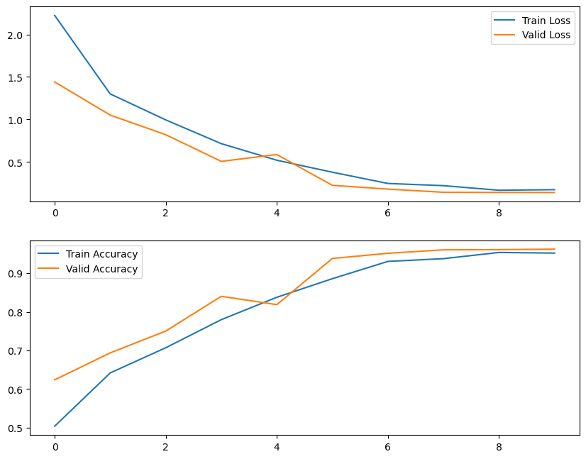

```python
# Display training metric values
plot_metrics(final_rnn_model)
```

```python
# Print prediction(s)
test_model(final_rnn_model, english_sentences, french_sentences, same_length=False)
```

```
English:
california is busy during september , and it is usually wet in fall .
French:
californie est occupé en septembre , et il est généralement humide à l' automne .
Translation:
californie est occupé en septembre et il est généralement humide à l' automne .
```

## Prediction (IMPLEMENTATION)

```python
def final_predictions(model, x, y, x_tk, y_tk):
    """
    Gets predictions using the final model
    :param x: Preprocessed English data
    :param y: Preprocessed French data
    :param x_tk: English tokenizer
    :param y_tk: French tokenizer
    """
    ## DON'T EDIT ANYTHING BELOW THIS LINE
    y_id_to_word = {value: key for key, value in y_tk.word_index.items()}
    y_id_to_word[0] = '<PAD>'

    sentence = 'he saw a old yellow truck'
    sentence = [x_tk.word_index[word] for word in sentence.split()]
    sentence = pad_sequences([sentence], maxlen=x.shape[-1], padding='post')
    sentences = np.array([sentence[0], x[0]])
    predictions = model.predict(sentences, len(sentences))

    print('Sample 1:')
    print(' '.join([y_id_to_word[np.argmax(x)] for x in predictions[0]]))
    print('Il a vu un vieux camion jaune')
    print('Sample 2:')
    print(' '.join([y_id_to_word[np.argmax(x)] for x in predictions[1]]))
    print(' '.join([y_id_to_word[np.max(x)] for x in y[0]]))
```

```python
# Run the benchmark test!
final_predictions(final_rnn_model, preproc_english_sentences, preproc_french_sentences, english_tokenizer, french_tokenizer)
```

```
Sample 1:
il a vu un vieux camion jaune <PAD> <PAD> <PAD> <PAD> <PAD> <PAD> <PAD> <PAD> <PAD> <PAD> <PAD> <PAD> <PAD> <PAD>
Il a vu un vieux camion jaune
Sample 2:
new jersey est parfois calme pendant l' automne et il est neigeux en avril <PAD> <PAD> <PAD> <PAD> <PAD> <PAD> <PAD>
new jersey est parfois calme pendant l' automne et il est neigeux en avril <PAD> <PAD> <PAD> <PAD> <PAD> <PAD> <PAD>
```

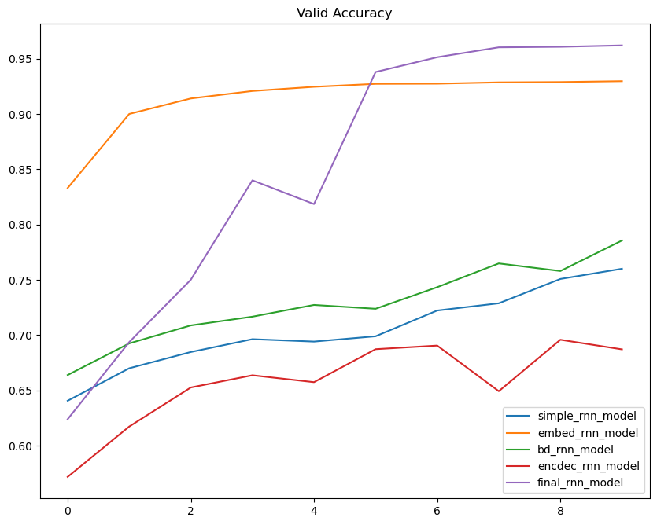

```python
# Compare all trained models!
models = [simple_rnn_model, embed_rnn_model, bd_rnn_model, encdec_rnn_model, final_rnn_model]
plot_comparison(models)
```

## Submission

When you're ready to submit, complete the following steps:

1. Review the [rubric](https://review.udacity.com/#!/rubrics/1004/view) to ensure your submission meets all requirements to pass
2. Generate an HTML version of this notebook
   - Run the next cell to attempt automatic generation (this is the recommended method in Workspaces)
   - Navigate to **FILE -> Download as -> HTML (.html)**
   - Manually generate a copy using `nbconvert` from your shell terminal

     ```
     $ pip install nbconvert
     $ python -m nbconvert machine_translation.ipynb
     ```

3. Submit the project
   - If you are in a Workspace, simply click the "Submit Project" button (bottom towards the right)
   - Otherwise, add the following files into a zip archive and submit them
   - `helper.py`
   - `machine_translation.ipynb`
   - `machine_translation.html`
     - You can export the notebook by navigating to **File -> Download as -> HTML (.html)**.

```python
!!python -m nbconvert *.ipynb --to html
```

```
['[NbConvertApp] Converting notebook machine_translation.ipynb to html',
 '[NbConvertApp] Writing 1061445 bytes to machine_translation.html']
```

## Optional Enhancements

This project focuses on learning various network architectures for machine translation, but we don't evaluate the models according to best practices by splitting the data into separate test & training sets -- so the model accuracy is overstated. Use the [`sklearn.model_selection.train_test_split()`](http://scikit-learn.org/stable/modules/generated/sklearn.model_selection.train_test_split.html) function to create separate training & test datasets, then retrain each of the models using only the training set and evaluate the prediction accuracy using the hold out test set. Does the "best" model change?